# Activité des structures d’urgences : panorama 2014 de la région ALSACE

RESURAL (JcB)

28/01/2015

Version mse à jour le: **Sun Aug 30 11:50:06 2015**

Ajout de la dernière version de Gilles

- nombre de passages pour 10.000 hab.
- nombre de SU pour 10.000 hab.
- nombre de lignes SMUR financées par une MIG
- nombre de siège de SMUR dont SMUR saisonnier dont antenne SMUR dont hélismur
- séparer privés lucratifs et ESPIC
- nombre de logicels et nombre de SU par région
- SAE 2014 ?
- augmentation par rapport année N-1 en tenant compte uniquement des établissements “stables”
- séparer chu et non chu, samu de chu et de non chu
- retour attendu pour le 4/9

# 1 Activité des structures d’urgences : panorama 2014 de la région ALSACE

Rapport 2014 respectant les préconisations de la FEDORU. Source: [Trame commune](https://docs.google.com/document/d/101LYVqVLeHZnrujfMm3aqBYfbOwx3CPEB3Y-Lbud2Ls/edit)

Le document de référence pour le rapport est: **V4 trame commune 2014 rapport inter région** (xps: /home/jcb/Documents/Resural/FEDORU/Trame_Commune/DOC/Trame commune 2014 rapport inter région (V4).docx)

**NOTE**: certaines informations utiles sont dans **RPU_Doc**.

# 2 LE MOT DU PRÉSIDENT DE LA FEDORU

La publication du panorama des urgences de la région __ALSACE__constitue une excellente occasion pour présenter la fédération des observatoires régionaux des urgences (FEDORU) qui compte **RESURAL** parmi ses membres actifs.

La FEDORU a été créée au mois d’octobre 2013. Ses membres sont chargés dans leur région respective du traitement des données d’urgences ; ce point commun est le trait d’origine de la FEDORU et donne son empreinte à l’objet de notre association que je cite ici :

- promouvoir les observatoires régionaux des urgences et les structures ayant une activité similaire ;
- promouvoir toutes les actions visant à améliorer la connaissance sur les soins de premier recours ;
- partager les expertises dans le domaine du recueil, de l’analyse et de l’évaluation de la qualité des données relatives à l’activité des urgences.

Les premières publications de la FEDORU (disponibles sur le site : http://www.fedoru.fr) abordent les thèmes techniques suivants :

- Recommandations pour la création d’un ORU
- Collecte et usage des RPU
- Hôpital en tension - Synthèse FEDORU

Ces documents constituent le socle indispensable à la conduite de travaux inter-régionaux. Nous pourrons ainsi comparer nos résultats, harmoniser les indicateurs retenus dans nos publications respectives, travailler sur des échantillons de données plus importants(inter-région ou national), mais aussi évaluer l’impact de différentes organisations.

**Dr G. VIUDES**

*Président de la FEDORU*

# 3 Description de l’offre de soins

## 3.1 Qualité des données

Réalisation d’un diagramme radar présentant l’exhaustivité des items RPU.

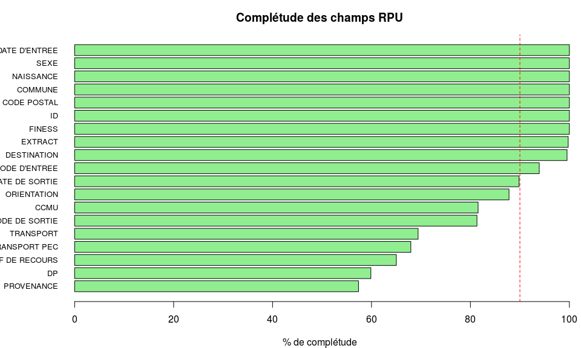

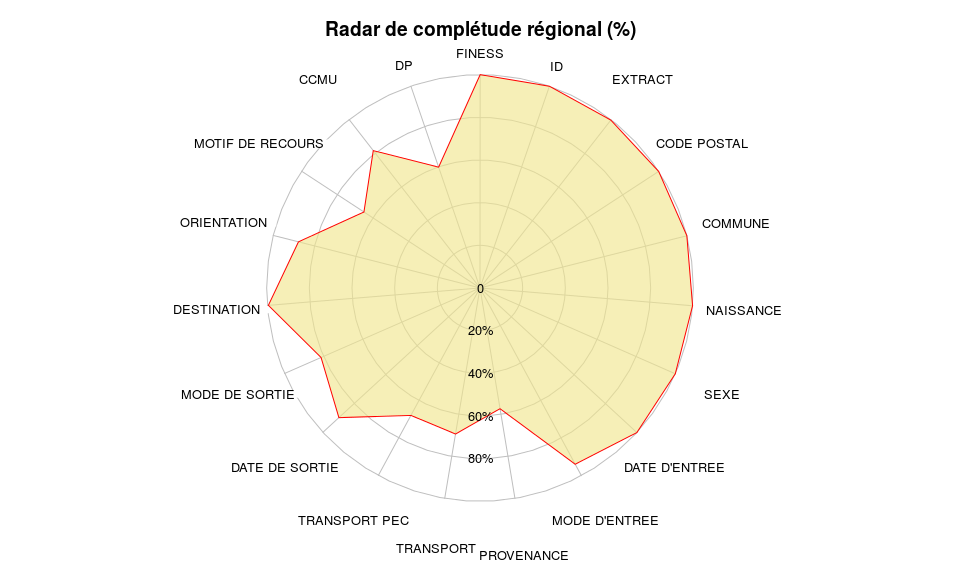

Complétude en valeur absolue et en pourcentages:`

```
##           FINESS               ID          EXTRACT      CODE POSTAL
##           416733           416733           415731           416733
##          COMMUNE        NAISSANCE             SEXE    DATE D'ENTREE
##           416716           416733           416733           416733
##    MODE D'ENTREE       PROVENANCE        TRANSPORT    TRANSPORT PEC
##           391370           239122           289308           283189
##   DATE DE SORTIE   MODE DE SORTIE      DESTINATION      ORIENTATION
##           374349           338878            82635            72898
## MOTIF DE RECOURS             CCMU               DP
##           270962           339827           245974
```

```
##           FINESS               ID          EXTRACT      CODE POSTAL
##              100              100              100              100
##          COMMUNE        NAISSANCE             SEXE    DATE D'ENTREE
##              100              100              100              100
##    MODE D'ENTREE       PROVENANCE        TRANSPORT    TRANSPORT PEC
##               94               57               69               68
##   DATE DE SORTIE   MODE DE SORTIE      DESTINATION      ORIENTATION
##               90               81              100               88
## MOTIF DE RECOURS             CCMU               DP
##               65               82               60
```

# 4 Les chiffres clés de l’activité des services d’urgences

Le format des chiffres clés est celui défini par la FEDORU. Il est commun à toutes les régions membres de la FEDORU.

## 4.1 Recueil des données

- Nombre de passages dans l’année: 432 170 (données SAE 2014)
- Nombre de RPU déclarés: **416 733 RPU**
- Exhaustivité du recueil: **96.43 %**
- Moyenne quotidienne de passages: **1 142 RPU/jour**
- %(N) d’évolution par rapport à année 2013: **22 %**.
- % d’évolution moyenne sur les 5 dernières années (méthode calcul : *pas de données disponibles*.
- Données renseignées (données à partir desquelles tout le reste de l’analyse sera effectuée) = Nombre de RPU transmis: 416 733 RPU

## 4.2 PATIENTS

### 4.2.2 Age

- age moyen: **38 ans**.
- age moyen des hommes: 35.9 ans.
- age moyen des femmes: 40.3 ans.
- % (N) < 1 an: 15 376 (**3.69 %**)
- %(N) < 15 ans: 103 413 (**24.82 %**)
- %(N) < 18 ans: 119 213 (**28.61 %**)
- %(N) >= 75 ans: 57 271 (**13.74 %**)
- Pyramide des ages:

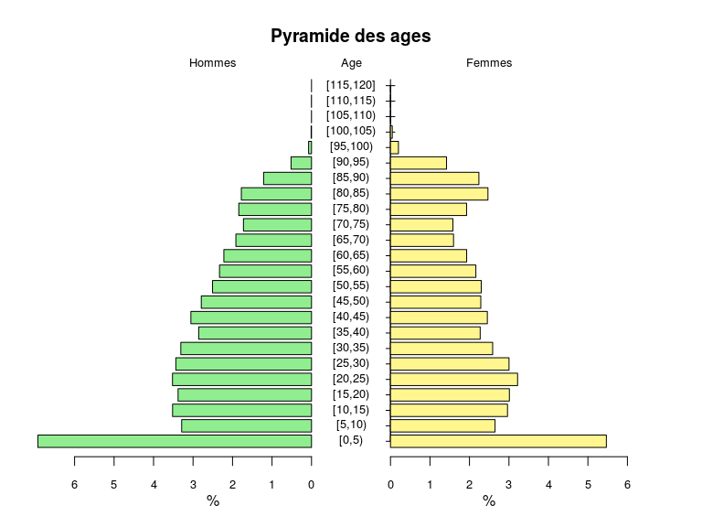

### 4.2.3 Taux de recours (définition FEDORU) régional aux urgences.

Le taux de recours régional est calculé à partir des données de l’INSEE.

TARRU: **21.31%** (ref: population alsacienne 2014)

## 4.3 ARRIVÉE

### 4.3.1 Horaires de passage

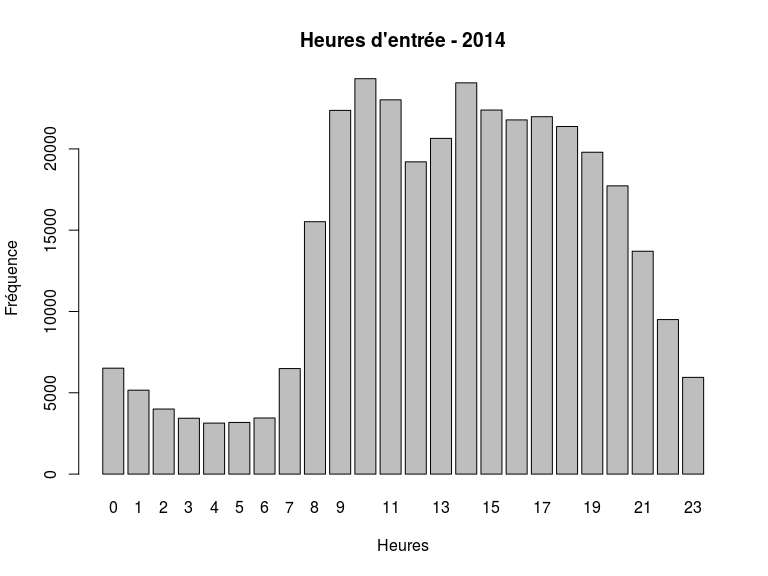

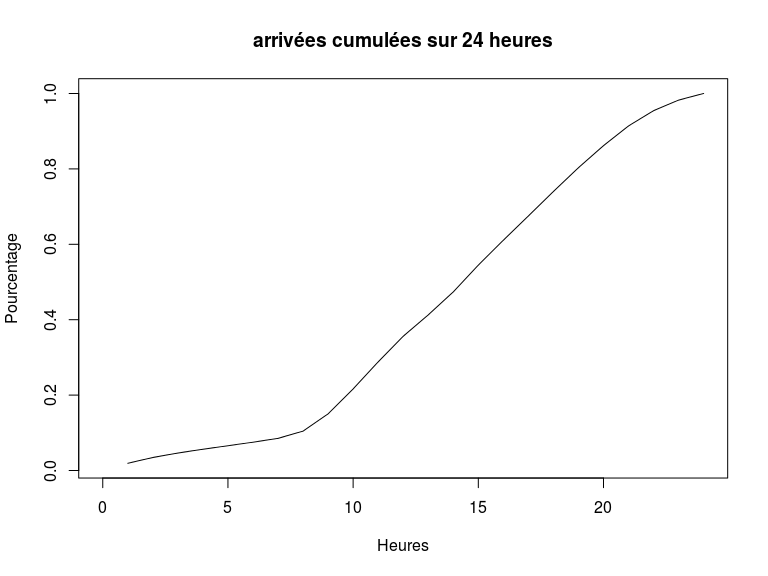

- Passages de nuit (20h - 8h): **27.7 %** (N = 115 418)
- Passages en nuit profonde (0h - 8h): **10.38 %** (N = 43 271)
- Passages en horaire de PDSA: **NA %** N = NA

### 4.3.2 Variations saisonnières

Variation du nombre de RPU entre les mois d’été (juillet-août) et les autres mois de l’année: **-5.82 %**.

### 4.3.3 Moyens d’arrivée

- %(N) d’arrivée personnel: **NA %** (N = NA)
- %(N) d’arrivée SMUR: **NA %** (N = NA)
- %(N) d’arrivée VSAB: **NA %** (N = NA)
- %(N) d’arrivée Ambulance: **NA %** (N = NA)

NB : commentaire possible pour expliquer que la somme des 4 pourcentages ci dessus ne fait pas 100 %

### 4.3.4 Gravité (CCMU)

- nombre de CCMU renseignés: 339 827.
- %(N) CCMU 1: **NA%** (n = NA)
- %(N) CCMU 1 et 2: **NA%** (n = NA)
- %(N) CCMU 4 et 5: **NA%** (n = NA)

Exhaustivité CCMU :

- Nombre de RPU 2014 hors orientation = FUGUE, PSA et REO ayant un élément transmis pour la CCMU: **335 889**.

### 4.3.5 Diadnostic principal

Remarque: les chiffres sont dans le document *Codes_regroupement_ORUMIP* => à rajouter.

- % Médico-chirurgical: **136 816**
- % Traumatologique: **91 907**
- % Psychiatrique: **6 185**
- % Toxicologique: **4 847**
- % Autres recours: **7 441**

### 4.3.6 Durées de passage

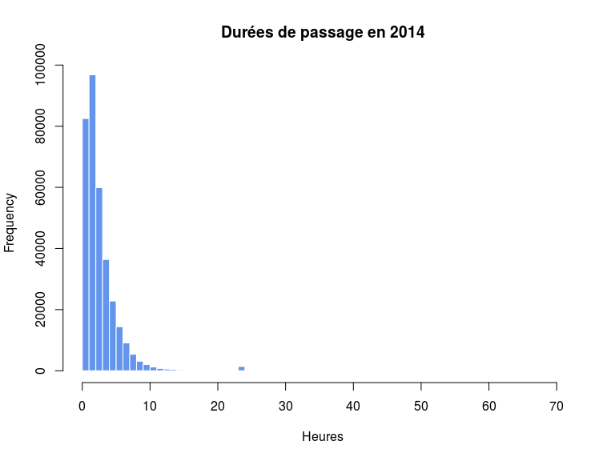

- Nombre de RPU dont la durée de passage est comprise entre 0h et 72h: **338 722**
- durée moyenne de passage **160 mn** (2h40).
- écart-type: 173.22 mn (2h53).
- médiane: **113 mn** (1h53).
- nombre de prises en charge > 4 heures: 63 101 (**18.63 %**).
- nombre de prises en charge inférieures ou égales à 4 heures: 275 621 (**81.37 %**).
- Lors d’une hospitalisation post-urgences (hospitalisation = mutation + transfert)
  - moyenne durée de passage en cas d’hospitalisation: **238.69 mn**.
  - médiane durée de passage en cas d’hospitalisation: **198 mn**.
- Lors d’un retour au domicile
  - moyenne durée de passage en cas de retour à domicile: **NA mn**.
  - médiane durée de passage en cas de retour à domicile: **NA mn**.

(source: temps de passages.Rmd)

### 4.3.7 Mode de sortie

- % (N) de retour à domicile: **75.5 %** (N = 255 852)
- % (N) Hospitalisation: **24.5 %** (N = 83 024)
- % (N) Mutation: **22.72 %** (N = 76 999)
- % (N) Transfert: **1.78 %** (N = 6 025)
- Nb de RPU 2014 avec mode de sortie = 6 ou 7 (hospitalisation) avec un élément transmis pour la destination: **82635**
- Nb de RPU 2014 avec mode de sortie = 6 ou 7 avec un élement transmis pour l’orientation: **72898**

# 5 Les chiffres clés de l’activité des SAMU

(à partir des données SRVA “officielles”)

## 5.1 Organisation

Nombre de colonnes SMUR:

| SMUR | Jour | Nuit |
| --- | --- | --- |
| Wissembourg | 1 | 1 |
| Haguenau | 1 | 1 |
| Saverne | 1 | 1 |
| Strasbourg | 4 | 3 |
| Sélestat | 1 | 1 |
| Colmar | 2 | 2 |
| Mulhouse | 2 | 2 |

# 6 Les chiffres clés de l’activité pédiatrique des services d’urgences (moins de 18 ans)

```
## ped
##      <28j  28j-1an[   1-5ans[  5-10ans[ 10-15ans[ 15-18ans[
##      1791     13554     36287     24738     27012     15800
```

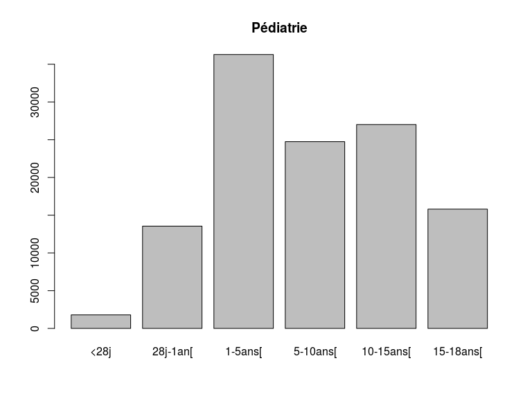

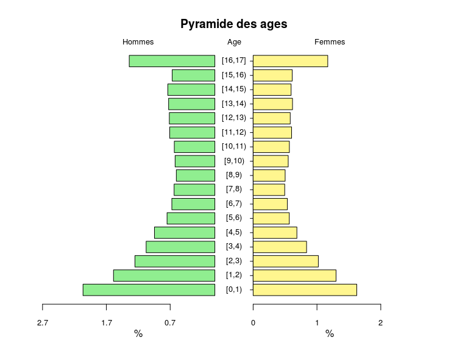

RECUEIL DES DONNÉES ——————- - Nombre de passages dans l’année: 119 213 - Moyenne quotidienne de passage: 327 passages/j - Taux d’urgences pédiatriques [(Nb RPU Pédia/ Nb RPU global)x100]: 29 % - TODO: % d’évolution par rapport à l’année N-1(données SAE pour ceux qui n’ont pas d’historique RPU fiable et permettant la comparaison, préciser l’origine des données)

## 6.1 PATIENTS

```
 AMBU    FO  HELI PERSO  SMUR  VSAB        NA's
 2024    81    17 71809   706  3053     0 41523
```

```
[1] 77690
```

```
[1] 94706
```

```
    1     2     3     4     5     D     P        NA's
24353 63361  6678   211    23     2    78     0 24507
```

- nombre de garçons: 65619
- nombre de filles: 53590
- Sex ratio: 1.22
- Pyramide des âges (âge par année, borne supérieure toujours exclue)
- Par sous classes d’âge:

### 6.1.1 horaires de passages pédiatriques

- nombre de passages la nuit: 32677, 0.27 (p = 27.41, 0 %)
- nombre de passages en nuit profonde: 8660, 0.07 (p = 7.26, 0 %)

# 7 Les chiffres clés de l’activité gériatrique des services d’urgences (75 ans et plus)

## 7.1 RECUEIL DES DONNÉES

- Nombre de passages dans l’année: 57 271
- Moyenne quotidienne de passage: 157 passages/j
- Taux d’urgences gériatriques [(Nb RPU Géria/ Nb RPU global)x100]: 13.74 %
- TODO: % d’évolution par rapport à l’année N-1(données SAE pour ceux qui n’ont pas d’historique RPU fiable et permettant la comparaison, préciser l’origine des données)

## 7.2 PATIENTS

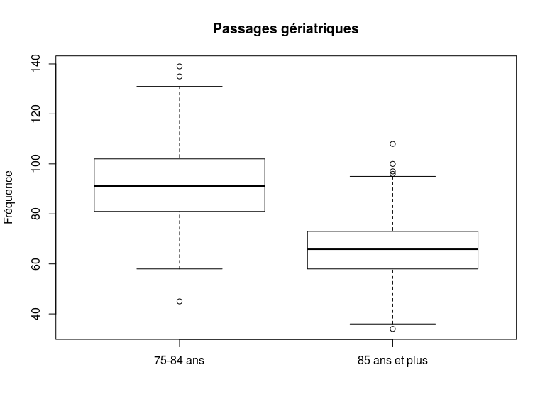

```
               effectif moyenne par jour  médiane par jour sex ratio
75-84 ans         33399                92               91      0.82
85 ans et plus    23872                65               66      0.47
```

- Nombre d’hommes: 22 665
- Nombre de femmes: 34 605
- Sex ratio: 0.65
- Pyramide des âges (âge par année, borne supérieure toujours exclue)
- Par sous classes d’âge:

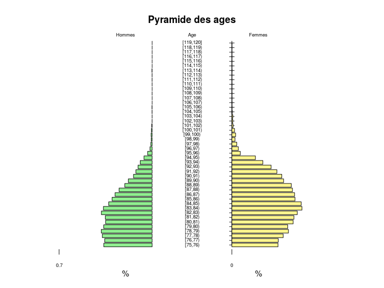

## 7.3 ARRIVÉE

### 7.3.1 Horaires de passage

- Nb de RPU avec date/heure d’entrée renseignés: 57 271
- % passages la nuit: 22.38 % (N = 12 815)
- % passages en horaire de PDS: NA % (N = NA)

### 7.3.2 Moyens de transport

- nombre de moyens de transport: 57271
- nombre de moyens de transport renseignés: 40878
- nombre de moyens personnels: NA
- nombre de SMUR: NA
- nombre de VSAV: NA
- nombre d’ambulances privées: NA
- % d’arrivées Moyen perso: 20.89 % (N = 11 962)
- % d’arrivées SMUR: 1.22 % (N = 698)
- % d’arrivées VSAV: 11.87 % (N = 6 797)
- % d’arrivées ambulance privée: 37.31 % (N = 21 370)
- % réponses manquantes:

NB : commentaire possible pour expliquer que la somme des 4 pourcentages ci dessus ne fait pas 100 %

### 7.3.3 Gravité

- Nombre de RPU avec une CCMU renseignée: 47408
- % CCMU 1: 4.32 % (N = 2 472)
- % CCMU 4 et 5: 3.14 % (N = 1 797)

### 7.3.4 Diagnostic principal

- % Médico-chirurgical: 55.35 %
  - dont :
  - % cardio vasculaire
- % neuro
- % digestif
- % respiratoire
- % Traumatologique: 37.18 %
  - % Psychiatrique: 2.5 %
  - % Toxicologique: 1.96 %
  - % Autres recours: 3.01 %

### 7.3.5 DURÉE

```
##        NA  Mutation Transfert  Domicile     Décès
##        NA       219       316       215        NA        NA
```

```
##        NA  Mutation Transfert  Domicile     Décès
##        NA       200       248       174        NA        NA
```

```
##
##  Welch Two Sample t-test
##
## data:  passages75$duree by passages75$DEVENIR
## t = -5, df = 40000, p-value = 0.000002
## alternative hypothesis: true difference in means is not equal to 0
## 95 percent confidence interval:
##  -12.7  -5.3
## sample estimates:
## mean in group Domicile     mean in group Hosp
##                    215                    224
```

```
## [1] 0.0000016
```

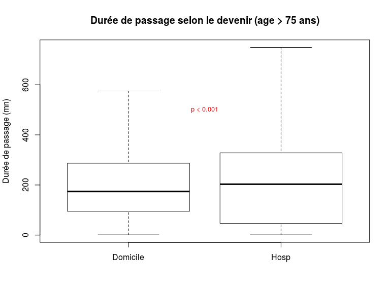

- Durée moyenne de passage (HORS UHCD) : 220 minutes
- Durée médiane de passage (HORS UHCD) : 190 minutes
- % de passages de moins de 4h : 61.22 %
- lors d’une hospitalisation post-urgences (hospitalisation = mutation + transfert): 223.7 minutes.
- lors d’un retour au domicile: 214.71 minutes.

#### 7.3.5.1 Nouveau

- Nombre de RPU avec une heure de sortie conforme (]0-72h[: 37603
- Durée moyenne de passage (en min): 246.62 mn
- Durée médiane de passage (en min): 210 mn
- Nombre de RPU dont la durée de passage est inférieure à 4h: 21716
- Nombre de RPU avec une heure de sortie conforme (]0-72h[ lors d’une hospitalisation post-urgences: 17066
- Nombre de RPU avec une heure de sortie conforme (]0-72h[ lors d’un retour au domicile: 17307
- Nombre de RPU dont la durée de passage est inférieure à 4h lors d’une hospitalisation post-urgences: 8109
- Nombre de RPU dont la durée de passage est inférieure à 4h lors d’un retour au domicile: 13607

### 7.3.6 MODE DE SORTIE

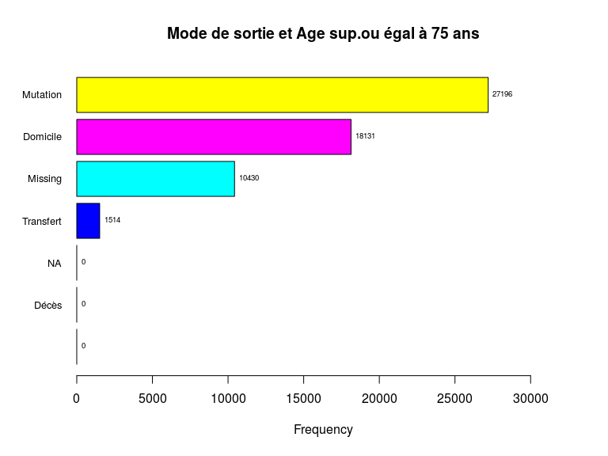

```
## pop75$MODE_SORTIE :
##           Frequency   %(NA+)   %(NA-)
## Mutation      27196     47.5     58.1
## Domicile      18131     31.7     38.7
## NA's          10430     18.2      0.0
## Transfert      1514      2.6      3.2
## NA                0      0.0      0.0
## Décès             0      0.0      0.0
##                   0      0.0      0.0
##   Total       57271    100.0    100.0
```

- % d’hospitalisation: 50.13 % (N = 28 710)
  - % de mutation:47.49 % (N = 27 196)
  - % de transfert:2.64 % (N = 1 514)
- % de retour à domicile:31.66 % (N = 18 131)

#### 7.3.6.1 rapport régional

- Nombre de RPU avec un mode de sortie renseigné: 46 841
- Nombre de mutation interne: 27 196
- Nombre de transfert externe: 1 514
- nombre de retours à domicile: 18 131

# 8 Les chiffres clés de l’activité AVC des services d’urgences

## 8.1 RECUEIL DES DONNÉES

- Nombre d’AVC dans l’année (+ rappeler le pourcentage d’exhaustivité du DP par rapport au nombre de RPU): **2 949**
- Moyenne quotidienne d’AVC: **8,1 AVC/j**
- % d’AVC dans l’activité globale: **1.19 %**

## 8.2 Répartition des AVC

Exemple d’utilisation de la méthode *hist* appliquée aux objets date-time:

- *x* = as.Date(AVC$ENTREE)
- *breaks* est obligatoire: “days”, “weeks”, “months”, “quarters”, “years”, “secs”, “mins”, “hours”. Utiliser *start.on.monday = TRUE* si *breaks = “weeks”*.
- *freq* = TRUE (défaut FALSE) pour afficher les fréquences
- *format* permet de coisir l’affichage de la date sur l’axe des x [voir](https://stat.ethz.ch/R-manual/R-devel/library/base/html/strptime.html).

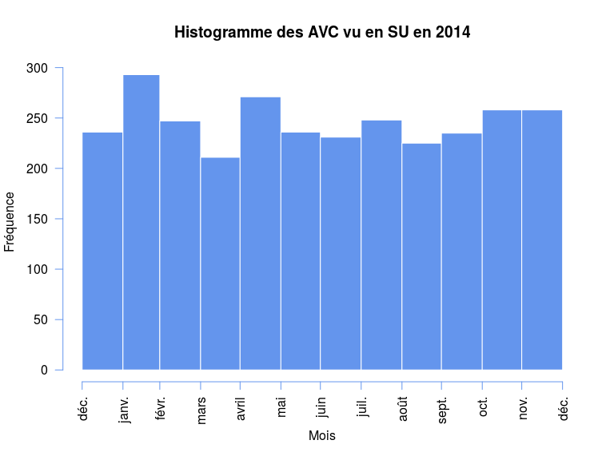

## 8.3 PATIENTS

```
## c.age
##     [0,5)    [5,10)   [10,15)   [15,20)   [20,25)   [25,30)   [30,35)
##        10         2         4        10        19        26        26
##   [35,40)   [40,45)   [45,50)   [50,55)   [55,60)   [60,65)   [65,70)
##        33        68        97       150       166       235       284
##   [70,75)   [75,80)   [80,85)   [85,90)   [90,95)  [95,100) [100,105)
##       295       393       496       408       193        28         4
## [105,110) [110,115) [115,120)
##         1         1         0
```

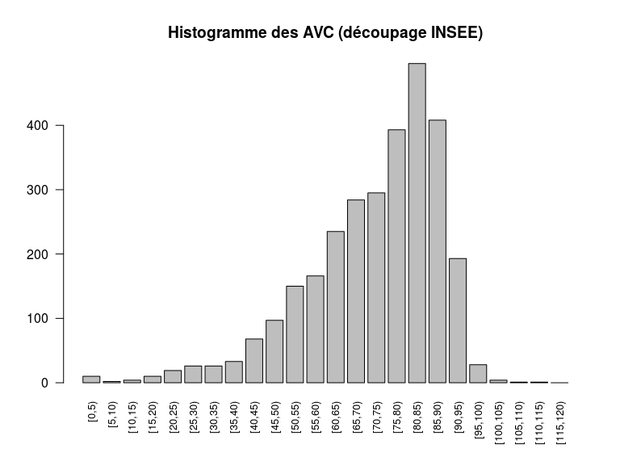

```
## c.age
##    [0,1)    [1,5)   [5,10)  [10,15)  [15,18)  [18,30)  [30,45)  [45,65)
##        3        7        2        4        4       51      127      648
##  [65,75)  [75,85) [85,120)
##      579      889      635
```

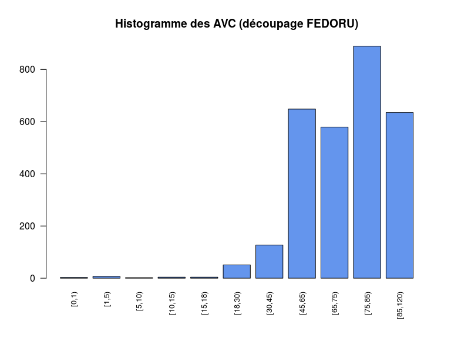

- Sex ratio: 0.95
- Age moyen: 71.44 ans
- Nombre d’AVC par sous classe d’âge (GT1):

## 8.4 ARRIVÉE

- Nombre d’AVC et % par tranche d’heure GT1 (matinée, début d’après midi, fin d’après midi, soirée, nuit profonde)

```
##      nuit profonde matinée  début après-midi fin après-midi soirée
## [1,] "[0,8)"       "[8,12)" "[12,16)"        "[16,20)"      "[20,24)"
## [2,] "272"         "900"    "865"            "619"          "293"
```

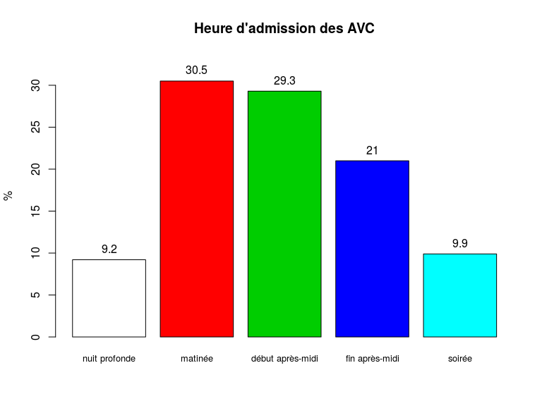

- % AVC le matin: 30.5 %.
- % AVC en début d’après-midi: 29.3 %.
- % AVC en fin d’après-midi: 21 %.
- % AVC en soirée: 9.9 %.
- % AVC le nuit profonde: 9.2 %.
- Nombre de passages AVC urgences, déclinaison par département, établissement, année N

```
## 3Fr Alk Ane Col Dia Dts Geb Hag Hus Mul Odi Ros Sav Sel Wis
##  63  30  NA 741  NA  NA  30 500 580 682  NA  NA  NA 238  85
```

- % passages en horaire de PDS

PDSS = horaires de PDS en semaine, PDSWE = horaires de PDS le WE, NPDS = hors horaire de PDS.

- nombre d’AVC aux horaires de PDS en semaine: 13.67 %
- nombre d’AVC aux horaires de PDS de week-end:22.24 %
- nombre d’AVC en dehors des horaires de PDS:64.09 %
- Nombre de RPU avec diag AVC avec date et heure d’entrées renseignées: 2 949

## 8.5 Mode d’arrivée aux urgences

```
##          n       n.na       p.na     n.rens     p.rens       n.fo
## 2949.00000  554.00000    0.18786 2395.00000    0.81214    1.00000
##     n.heli    n.perso     n.smur     n.vsav     n.ambu       p.fo
##   19.00000  636.00000   58.00000  527.00000 1154.00000    0.00042
##     p.heli    p.perso     p.smur     p.vsav     p.ambu
##    0.00793    0.26555    0.02422    0.22004    0.48184
```

## 8.6 Diagnostic principal

- Nombre d’AVC ischémiques et %: 1 021 (34.62 %)
- Nombre d’AVC hémorragiques et %: 442 (14.99 %)
- Nombre d’AIT et %: 806 (27.33 %)
- Nombre de codes “symptomatiques” (hémiplégie, aphasie, amaurose, etc…) et %: 680 (23.06 %)

## 8.7 DURÉE

Voir les routines de RPU_2014/Analyse/Temps_passage/passage.R et notamment **temps de passage**.

## 8.8 MODE DE SORTIE

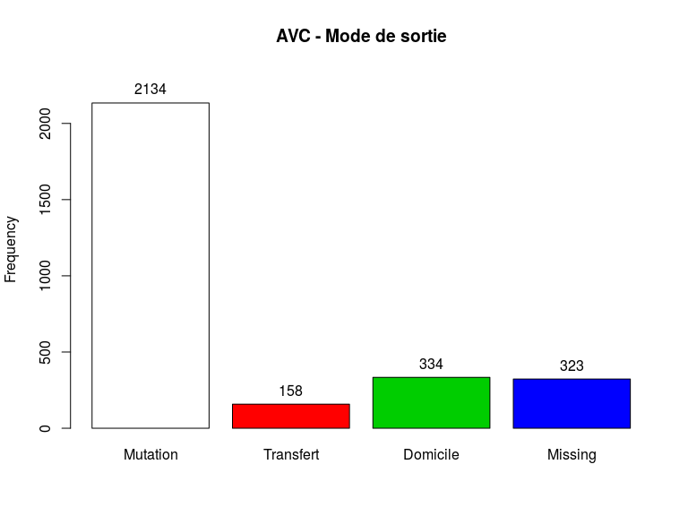

- Nombre de RPU ac diag. AVC avec un mode de sortie renseigné: 2626
- % d’hospitalisation: 87.3 % (N = 2292)
- % de mutation: 81.3 % (N = 2134)
- % de transfert: 6 % (N = 158)
- % de retour à domicile: 12.7 % (N = 334)

# 9 Analyse par type d’étblissement

Voir routine **analyse-type_etablissement** (rapport_2014.R).

## 9.1 SU de CHU

Un seul établissement **HUS** avec 3 SU:

- NHC
- HTP Adultes
- HTP Pédiatrie

```
## [1] 61793
```

```
##          n       n.na       p.na     n.rens     p.rens   n.inf1an
##  61793.000      0.000      0.000  61793.000      1.000  15376.000
## n.inf15ans n.inf18ans    n.75ans    n.85ans    n.90ans   p.inf1an
## 103413.000 119213.000  57271.000  23872.000   9487.000      0.037
## p.inf15ans p.inf18ans    p.75ans    p.85ans    p.90ans   mean.age
##      0.248      0.286      0.137      0.057      0.023     42.400
##     sd.age median.age    min.age    max.age         q1         q3
##     29.320     41.000      0.000    110.000     16.000     68.000
```

```
##           n        n.na        p.na      n.rens      p.rens n.residents
##       61793           0           0       61793           1       59288
## n.etrangers
##        2505
```

```
##  Lun  Mar  Mer  Jeu  Ven  Sam  Dim
## 9211 8980 8527 8667 9170 8806 8432
```

```
##          n       n.na       p.na     n.rens     p.rens   n.inf1an
##  61793.000      0.000      0.000  61793.000      1.000  15376.000
## n.inf15ans n.inf18ans    n.75ans    n.85ans    n.90ans   p.inf1an
## 103413.000 119213.000  57271.000  23872.000   9487.000      0.037
## p.inf15ans p.inf18ans    p.75ans    p.85ans    p.90ans   mean.age
##      0.248      0.286      0.137      0.057      0.023     42.400
##     sd.age median.age    min.age    max.age         q1         q3
##     29.320     41.000      0.000    110.000     16.000     68.000
```

```
## [1] 22681.00     0.37
```

```
##
##  NPDS
## 61793
```

```
##      n   n.na   p.na n.rens p.rens
##  61793      0      0  61793      1
```

```
##           n        n.na        p.na      n.rens      p.rens        n.fo
## 61793.00000 53476.00000     0.86541  8317.00000     0.13459    47.00000
##      n.heli     n.perso      n.smur      n.vsav      n.ambu        p.fo
##     2.00000  1214.00000   274.00000  2262.00000  4518.00000     0.00565
##      p.heli     p.perso      p.smur      p.vsav      p.ambu
##     0.00024     0.14597     0.03294     0.27197     0.54322
```

```
##         n      n.na      p.na    n.rens    p.rens   n.ccmu1   n.ccmu2
## 61793.000 28298.000     0.458 33495.000     0.542  8743.000 17870.000
##   n.ccmu3   n.ccmu4   n.ccmu5   n.ccmup   n.ccmud   p.ccmu1   p.ccmu2
##  6178.000   503.000   201.000        NA        NA     0.261     0.534
##   p.ccmu3   p.ccmu4   p.ccmu5   p.ccmup   p.ccmud
##     0.184     0.015     0.006        NA        NA
```

```
##                 n.conforme      duree.moyenne.passage
##                      26416                        254
##      duree.mediane.passage  duree.moyenne.passage.dom
##                        141                         NA
##  duree.mediane.passage.dom duree.moyenne.passage.hosp
##                         NA                        346
## duree.mediane.passage.hosp                 n.passage4
##                        312                      17899
##            n.hosp.passage4             n.dom.passage4
##                       1225                      16674
##                      n.dom                     n.hosp
##                       2958                       3320
##                n.transfert                 n.mutation
##                        115                       3205
##                    n.deces
##                          0
```

```
##           n        n.na        p.na      n.rens      p.rens       n.dom
##  61793.0000  35337.0000      0.5719  26456.0000      0.4281   3122.0000
##      n.hosp n.transfert  n.mutation     n.deces       p.dom      p.hosp
##  23334.0000    115.0000  23219.0000      0.0000      0.1180      0.8820
## p.transfert  p.mutation     p.deces
##      0.0043      0.8776      0.0000
```

## 9.2 SU d’ES siège de SAMU, non CHU

Un seul établissement: CH de Mulhouse avec 2 implantations:

- Emile Muller (Adultes + Pédiatrie traumatique)
- Hasenrain (Pédiatrie médicale)

```
[1] 59471
```

```
         n       n.na       p.na     n.rens     p.rens   n.inf1an
 59471.000      0.000      0.000  59471.000      1.000  15376.000
n.inf15ans n.inf18ans    n.75ans    n.85ans    n.90ans   p.inf1an
103413.000 119213.000  57271.000  23872.000   9487.000      0.037
p.inf15ans p.inf18ans    p.75ans    p.85ans    p.90ans   mean.age
     0.248      0.286      0.137      0.057      0.023     34.600
    sd.age median.age    min.age    max.age         q1         q3
    28.078     30.000      0.000    113.000      8.000     57.000
```

```
          n        n.na        p.na      n.rens      p.rens n.residents
      59471           0           0       59471           1       57952
n.etrangers
       1519
```

```
 Lun  Mar  Mer  Jeu  Ven  Sam  Dim
8868 7885 8130 7931 8270 8854 9533
```

```
         n       n.na       p.na     n.rens     p.rens   n.inf1an
 59471.000      0.000      0.000  59471.000      1.000  15376.000
n.inf15ans n.inf18ans    n.75ans    n.85ans    n.90ans   p.inf1an
103413.000 119213.000  57271.000  23872.000   9487.000      0.037
p.inf15ans p.inf18ans    p.75ans    p.85ans    p.90ans   mean.age
     0.248      0.286      0.137      0.057      0.023     34.600
    sd.age median.age    min.age    max.age         q1         q3
    28.078     30.000      0.000    113.000      8.000     57.000
```

```
[1] 18349.00     0.31
```

```
 NPDS
59471
```

```
     n   n.na   p.na n.rens p.rens
 59471      0      0  59471      1
```

```
         n       n.na       p.na     n.rens     p.rens       n.fo
59471.0000  3836.0000     0.0645 55635.0000     0.9355   478.0000
    n.heli    n.perso     n.smur     n.vsav     n.ambu       p.fo
  122.0000 35973.0000   223.0000  7051.0000 11788.0000     0.0086
    p.heli    p.perso     p.smur     p.vsav     p.ambu
    0.0022     0.6466     0.0040     0.1267     0.2119
```

```
         n       n.na       p.na     n.rens     p.rens    n.ccmu1
59471.0000 14043.0000     0.2361 45428.0000     0.7639  7349.0000
   n.ccmu2    n.ccmu3    n.ccmu4    n.ccmu5    n.ccmup    n.ccmud
30451.0000  6094.0000  1235.0000   299.0000         NA         NA
   p.ccmu1    p.ccmu2    p.ccmu3    p.ccmu4    p.ccmu5    p.ccmup
    0.1618     0.6703     0.1341     0.0272     0.0066         NA
   p.ccmud
        NA
```

```
                n.conforme      duree.moyenne.passage
                     47518                        184
     duree.mediane.passage  duree.moyenne.passage.dom
                       151                         NA
 duree.mediane.passage.dom duree.moyenne.passage.hosp
                        NA                        244
duree.mediane.passage.hosp                 n.passage4
                       219                      34593
           n.hosp.passage4             n.dom.passage4
                      4159                      30434
                     n.dom                     n.hosp
                     35746                       7543
               n.transfert                 n.mutation
                       135                       7408
                   n.deces
                         0
```

```
          n        n.na        p.na      n.rens      p.rens       n.dom
 59471.0000  14257.0000      0.2397  45214.0000      0.7603  36717.0000
     n.hosp n.transfert  n.mutation     n.deces       p.dom      p.hosp
  8497.0000    150.0000   8347.0000      0.0000      0.8121      0.1879
p.transfert  p.mutation     p.deces
     0.0033      0.1846      0.0000
```

## 9.3 SU avec SMUR non siège de SAMU

SU abec SMUR sans SAMU, 5 établissements:

- CH Wissembourg
- CH haguenau
- CH Saverne
- CH Sélestat
- CH Colmar

```
[1] 177747
```

```
         n       n.na       p.na     n.rens     p.rens   n.inf1an
177747.000      0.000      0.000 177747.000      1.000  15376.000
n.inf15ans n.inf18ans    n.75ans    n.85ans    n.90ans   p.inf1an
103413.000 119213.000  57271.000  23872.000   9487.000      0.037
p.inf15ans p.inf18ans    p.75ans    p.85ans    p.90ans   mean.age
     0.248      0.286      0.137      0.057      0.023     37.300
    sd.age median.age    min.age    max.age         q1         q3
    27.737     33.000      0.000    120.000     13.000     59.000
```

```
          n        n.na        p.na      n.rens      p.rens n.residents
     177747           0           0      177747           1      166676
n.etrangers
      11071
```

```
  Lun   Mar   Mer   Jeu   Ven   Sam   Dim
27415 24007 24628 24099 24688 25896 27014
```

```
         n       n.na       p.na     n.rens     p.rens   n.inf1an
177747.000      0.000      0.000 177747.000      1.000  15376.000
n.inf15ans n.inf18ans    n.75ans    n.85ans    n.90ans   p.inf1an
103413.000 119213.000  57271.000  23872.000   9487.000      0.037
p.inf15ans p.inf18ans    p.75ans    p.85ans    p.90ans   mean.age
     0.248      0.286      0.137      0.057      0.023     37.300
    sd.age median.age    min.age    max.age         q1         q3
    27.737     33.000      0.000    120.000     13.000     59.000
```

```
[1] 46677.00     0.26
```

```
  NPDS
177747
```

```
     n   n.na   p.na n.rens p.rens
177747      0      0 177747      1
```

```
          n        n.na        p.na      n.rens      p.rens        n.fo
177747.0000  41213.0000      0.2319 136534.0000      0.7681    760.0000
     n.heli     n.perso      n.smur      n.vsav      n.ambu        p.fo
    95.0000  97489.0000   1603.0000  14816.0000  21771.0000      0.0056
     p.heli     p.perso      p.smur      p.vsav      p.ambu
     0.0007      0.7140      0.0117      0.1085      0.1595
```

```
           n         n.na         p.na       n.rens       p.rens
177747.00000  21649.00000      0.12180 156098.00000      0.87820
     n.ccmu1      n.ccmu2      n.ccmu3      n.ccmu4      n.ccmu5
 27108.00000 101455.00000  24309.00000   1547.00000    385.00000
     n.ccmup      n.ccmud      p.ccmu1      p.ccmu2      p.ccmu3
  1273.00000     21.00000      0.17366      0.64994      0.15573
     p.ccmu4      p.ccmu5      p.ccmup      p.ccmud
     0.00991      0.00247      0.00816      0.00013
```

```
                n.conforme      duree.moyenne.passage
                    158099                        164
     duree.mediane.passage  duree.moyenne.passage.dom
                       120                         NA
 duree.mediane.passage.dom duree.moyenne.passage.hosp
                        NA                        245
duree.mediane.passage.hosp                 n.passage4
                       206                     126600
           n.hosp.passage4             n.dom.passage4
                     18044                     108555
                     n.dom                     n.hosp
                    125505                      30709
               n.transfert                 n.mutation
                      2840                      27869
                   n.deces
                         1
```

```
            n          n.na          p.na        n.rens        p.rens
177747.000000  10215.000000      0.057469 167532.000000      0.942531
        n.dom        n.hosp   n.transfert    n.mutation       n.deces
126977.000000  40554.000000   2990.000000  37564.000000      1.000000
        p.dom        p.hosp   p.transfert    p.mutation       p.deces
     0.757927      0.242067      0.017847      0.224220      0.000006
```

## 9.4 SU non SMUR, non SAMU, non CHU

- Ste Anne
- Ste Odile
- Diaconat Strasbourg
- CH de Guebwiller
- CH de Thann (pas de RPU)
- CH d’Altkirch
- Clinique des 3 frontières
- Roosvelt
- Fonderie

```
[1] 117722
```

```
            n          n.na          p.na        n.rens        p.rens
117722.000000      4.000000      0.000034 117718.000000      0.999966
     n.inf1an    n.inf15ans    n.inf18ans       n.75ans       n.85ans
 15376.000000 103413.000000 119213.000000  57271.000000  23872.000000
      n.90ans      p.inf1an    p.inf15ans    p.inf18ans       p.75ans
  9487.000000      0.036897      0.248154      0.286068      0.137430
      p.85ans       p.90ans      mean.age        sd.age    median.age
     0.057284      0.022765     38.500000     23.926814     35.000000
      min.age       max.age            q1            q3
     0.000000    108.000000     19.000000     56.000000
```

```
          n        n.na        p.na      n.rens      p.rens n.residents
     117722           0           0      117722           1      114350
n.etrangers
       3372
```

```
  Lun   Mar   Mer   Jeu   Ven   Sam   Dim
18645 15880 16232 16002 16456 17567 16940
```

```
            n          n.na          p.na        n.rens        p.rens
117722.000000      4.000000      0.000034 117718.000000      0.999966
     n.inf1an    n.inf15ans    n.inf18ans       n.75ans       n.85ans
 15376.000000 103413.000000 119213.000000  57271.000000  23872.000000
      n.90ans      p.inf1an    p.inf15ans    p.inf18ans       p.75ans
  9487.000000      0.036897      0.248154      0.286068      0.137430
      p.85ans       p.90ans      mean.age        sd.age    median.age
     0.057284      0.022765     38.500000     23.926814     35.000000
      min.age       max.age            q1            q3
     0.000000    108.000000     19.000000     56.000000
```

```
[1] 27711.00     0.24
```

```
  NPDS
117722
```

```
     n   n.na   p.na n.rens p.rens
117722      0      0 117722      1
```

```
            n          n.na          p.na        n.rens        p.rens
117722.000000  28900.000000      0.245494  88822.000000      0.754506
         n.fo        n.heli       n.perso        n.smur        n.vsav
   264.000000      1.000000  74095.000000    602.000000   5825.000000
       n.ambu          p.fo        p.heli       p.perso        p.smur
  8035.000000      0.002972      0.000011      0.834196      0.006778
       p.vsav        p.ambu
     0.065581      0.090462
```

```
            n          n.na          p.na        n.rens        p.rens
117722.000000  12916.000000      0.109716 104806.000000      0.890284
      n.ccmu1       n.ccmu2       n.ccmu3       n.ccmu4       n.ccmu5
  8482.000000  85521.000000  10593.000000    147.000000     24.000000
      n.ccmup       n.ccmud       p.ccmu1       p.ccmu2       p.ccmu3
    34.000000      5.000000      0.080930      0.815993      0.101072
      p.ccmu4       p.ccmu5       p.ccmup       p.ccmud
     0.001403      0.000229      0.000324      0.000048
```

```
                n.conforme      duree.moyenne.passage
                    106689                        120
     duree.mediane.passage  duree.moyenne.passage.dom
                        87                         NA
 duree.mediane.passage.dom duree.moyenne.passage.hosp
                        NA                        174
duree.mediane.passage.hosp                 n.passage4
                       135                      96529
           n.hosp.passage4             n.dom.passage4
                      7050                      89478
                     n.dom                     n.hosp
                     86531                       9031
               n.transfert                 n.mutation
                      2575                       6456
                   n.deces
                         1
```

```
           n         n.na         p.na       n.rens       p.rens
117722.00000  18046.00000      0.15329  99676.00000      0.84671
       n.dom       n.hosp  n.transfert   n.mutation      n.deces
 89036.00000  10639.00000   2770.00000   7869.00000      1.00000
       p.dom       p.hosp  p.transfert   p.mutation      p.deces
     0.89325      0.10674      0.02779      0.07895      0.00001
```

Test de la routine et tableau compact

```
##                 es.chu es.samu es.smur es.simple
## n.passages       61793   59471  177747    117722
## n.age.ren        61793   59471  177747    117718
## n.inf1an         15376   15376   15376     15376
## n.inf15ans      103413  103413  103413    103413
## n.75ans          57271   57271   57271     57271
## n.cp.rens        61793   59471  177747    117722
## n.etrangers       2505    1519   11071      3372
## n.lun             9211    8868   27415     18645
## n.mar             8980    7885   24007     15880
## n.mer             8527    8130   24628     16232
## n.jeu             8667    7931   24099     16002
## n.ven             9170    8270   24688     16456
## n.sam             8806    8854   25896     17567
## n.dim             8432    9533   27014     16940
## n.nuit           22681   18349   46677     27711
## n.pds               NA      NA      NA        NA
## n.h.rens         61793   59471  177747    117722
## n.trans.rens      8317   55635  136534     88822
## n.fo                NA      NA      NA        NA
## n.heli              NA      NA      NA        NA
## n.perso             NA      NA      NA        NA
## n.smur              NA      NA      NA        NA
## n.vsav              NA      NA      NA        NA
## n.ambu              NA      NA      NA        NA
## n.ccmu.rens      33495   45428  156098    104806
## n.ccmu1             NA      NA      NA        NA
## n.ccmu2             NA      NA      NA        NA
## n.ccmu3             NA      NA      NA        NA
## n.ccmu4             NA      NA      NA        NA
## n.ccmu5             NA      NA      NA        NA
## n.ccmuP             NA      NA      NA        NA
## n.ccmuD             NA      NA      NA        NA
## n.ccmu45            NA      NA      NA        NA
## n.sorties.conf   26416   47518  158099    106689
## mean.passage       254     184     164       120
## median.passage     141     151     120        87
## n.passage4       17899   34593  126600     96529
## n.hosp.passage4   1225    4159   18044      7050
## n.dom.passage4   16674   30434  108555     89478
## n.dom             2958   35746  125505     86531
## n.hosp            3320    7543   30709      9031
## n.transfert        115     135    2840      2575
## n.deces              0       0       1         1
## n.mode.sortie    26456   45214  167532     99676
## n.mutation2      23219    8347   37564      7869
```

## 9.5 Doublons ?

- Age moyen, année N
- Répartition par classe âge en pourcentage, année N
- Répartition par sexe en pourcentage, année N
- TOP 5 pourcentage par code CIM 10, année N
- Répartition we/semaine en pourcentage, année N
- Répartition par tranche heure en pourcentage, année N

# 10 ANNEXES

## 10.1 ANNEXE 1 : Définitions

[output not shown]